# R Notebook

Simulate and fit a model allowing linear effects on variance as well as mean. This example requires the `rjags` package which itself requires a separate installation of [JAGS](http://sourceforge.net/projects/mcmc-jags/files/).

```r
# load the rjags library
library(rjags)
library(tidyverse)
```

Simulate the data

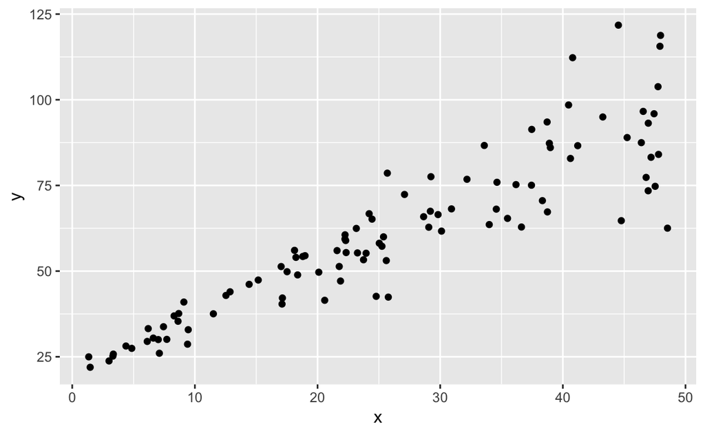

```r
# how many observations to simulate
n.obs <- 100
# intercept of the mean
b0 <- 20
# slope of the mean
b1 <- 1.6
# intercept of the standard deviation
a0 <- 1
# slope of the standard deviaion
a1 <- 0.04
# x is random between 0 and 100
x <- runif(n.obs, 0, 50)
# generate the y value mean determined by linear function of x with parameters
# b0 abd b1 and sd that is a function of x with parameters a0 and a1.
# Specifically the standard deviatoin is modelled as
# exponential  linear effect to ensure positive values only.
y <- rnorm(n.obs,
           mean = b0 + b1 * x,
           sd = exp(a0 + a1 * x) )
df <- data.frame(x = x, y = y)
# plot the raw data to check
ggplot(df, aes(x = x, y = y)) + geom_point()
```

# Bayesian model to recover the parameters

Define a JAGS model which in this case is identical to the model used to simulate the data: advantage of omniscience!

```r
modelstring ='
model {
  # Define the Likelihood
  for(i in 1:N) {
    # calculate the mean for each y[i]
    mu[i] <- b0 + b1 * x[i]
    # and similar for the standard deviation
    # which also needs to be converted to precision for JAGS.
    sigma[i] <- exp(a0 + a1 * x[i])
    tau[i] <- sigma[i] ^ -2
    # and finally the likelihood of the data
    y[i] ~ dnorm(mu[i], tau[i])

  }
  # -------------------------------------------
  # Prior distributions on our four parameters
  # Note: vague priors
  b0 ~ dnorm(0, 100^-2)
  b1 ~ dnorm(0, 100^-2)
  a0 ~ dnorm(0, 100^-2)
  a1 ~ dnorm(0, 100^-2)
}
'
# open teh text connection to this string
txtconn <- textConnection(modelstring)
```

Now we are ready to collect the data and pass it to the rjags fitting functions.

```r
# bundle the data into a list for passing to rjags
data <- list(x = df$x,
             y = df$y,
             N = nrow(df))
# set up the model
model <- jags.model(textConnection(modelstring),
                    data= data,
                    n.chains = 3)
```

[output not shown]

```r
# evaluate the model
output <- coda.samples(model = model,
                       variable.names = c("b0", "b1", "a0","a1"),
                       n.iter = 2000)
```

[output not shown]

```r
# tidy up and close the text connection
close(txtconn)
```

# Plot the output

Plot density plots of the esimates for each of our four parameters which are the slopes and intercepts for both the mean and the standard deviation.

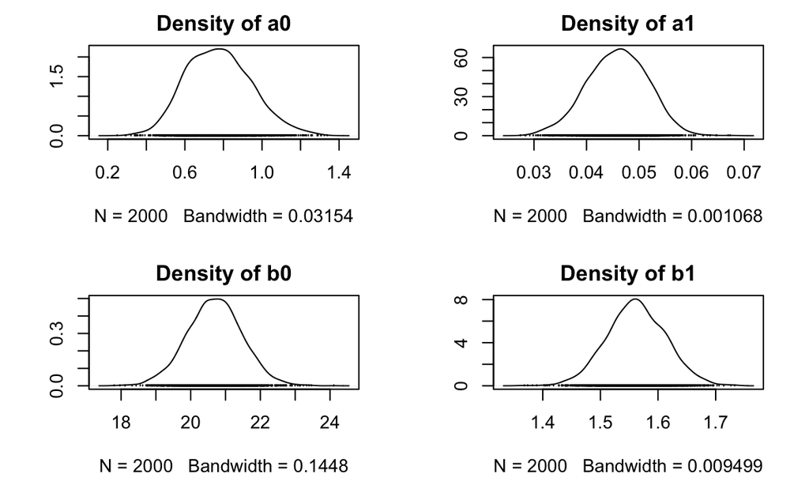

Plot trace plots to see how the algorithm has converged.

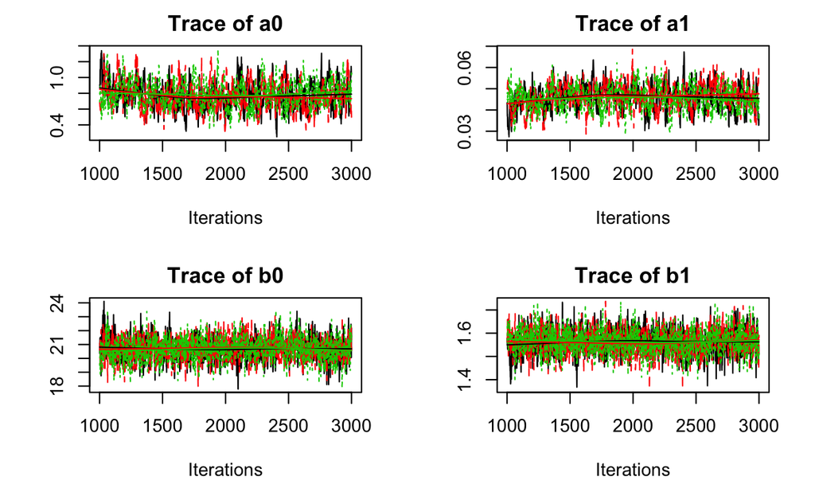

```r
plot(output, trace = TRUE, density = FALSE)
```

And test for convergence using the Gelman-Rubin-Brooks diagnostic. As a rule of thumb, values under 1.1 are what we are looking for.

```r
gelman.diag(output)
```

```
Potential scale reduction factors:

   Point est. Upper C.I.
a0       1.01       1.03
a1       1.01       1.03
b0       1.00       1.00
b1       1.00       1.00

Multivariate psrf

1.01
```

# Summary of Model

```r
# calculate summary statistics of the parameter estimates
summ_output <- summary(output)
# print to scrren
print(summ_output)
```

```
Iterations = 1001:3000
Thinning interval = 1
Number of chains = 3
Sample size per chain = 2000

1. Empirical mean and standard deviation for each variable,
   plus standard error of the mean:

       Mean       SD  Naive SE Time-series SE
a0  0.77763 0.169498 2.188e-03      0.0084440
a1  0.04586 0.005739 7.409e-05      0.0002865
b0 20.68858 0.792885 1.024e-02      0.0204344
b1  1.56241 0.051202 6.610e-04      0.0013077

2. Quantiles for each variable:

       2.5%      25%      50%      75%   97.5%
a0  0.47750  0.65295  0.77101  0.89207  1.1382
a1  0.03413  0.04194  0.04602  0.04992  0.0566
b0 19.12359 20.16486 20.69162 21.20740 22.2349
b1  1.46237  1.52877  1.56191  1.59718  1.6635
```

```r
# compare with the values specified by turning into a data.frame
# and removing some unnecessary columns
compare_coefs <- data.frame(summ_output$statistics[,1:2])
compare_coefs$True_Mean <- c(a0, a1, b0, b1)
compare_coefs$Diff_Mean <- compare_coefs$Mean - compare_coefs$True_Mean
knitr::kable(compare_coefs, digits = 2, padding = 20)
```

|  | Mean | SD | True_Mean | Diff_Mean |
| --- | --- | --- | --- | --- |
| a0 | 0.78 | 0.17 | 1.00 | -0.22 |
| a1 | 0.05 | 0.01 | 0.04 | 0.01 |
| b0 | 20.69 | 0.79 | 20.00 | 0.69 |
| b1 | 1.56 | 0.05 | 1.60 | -0.04 |

## Interpreting the results

Since `a1` in the code above controls the slope of the standard deviation with `x` on an exponential scale, then values different from 0 indicate heterscedacity. If we look at the summary table for the Quantiles, then 0 lies outside the 95% credible interval (i.e. between 2.5% and 97.5%) of a1.